# Filiacão partidária na capital paulista

Recentemente, o Tribunal Superior Eleitoral [(TSE)](http://www.tse.jus.br/) divulgou que atualmente no Brasil existem mais de 16 milhões de pessoas filiadas em partidos políticos. Detalha em [reportagem veiculada](http://www.tse.jus.br/imprensa/noticias-tse/2020/Julho/brasil-tem-16-4-milhoes-de-filiados-a-partidos-politicos)

> o Brasil tem hoje 16.499.493 pessoas filiadas a partidos políticos no país, sendo 9.015.650 do sexo masculino, 7.476.783 do sexo feminino e 7.060 sem gênero informado. Das 33 legendas registradas no TSE, o Movimento Democrático Brasileiro (MDB) é o que tem mais filiados: 2.163.450 pessoas

São Paulo, segundo os dados divulgados, é o estado com maior número de eleitores filiados, com 3.092.214. Também a capital paulista, [o maior colégio eleitoral municipal do país](https://tse.jusbrasil.com.br/noticias/68479/tre-sp-maior-e-o-menor-eleitorado-estao-em-sao-paulo), com mais de 8 milhões de eleitores, ocupa o primeiro lugar em número de filiados regulares, com 525 mil filiados.

Mas, como estão distribuídos esses filiados entre os partidos políticos na capital paulista, qual o histórico de filiação e como os partidos tem atraído ou não simpatizantes nos anos mais recentes?

Os dados dessa postagem foram extraídos do TSE, com o auxílio do pacote electionsBR[^1], e construídos no [programa R](https://cran.r-project.org/), cujos códigos estão disponíveis para reprodução em meu [github](https://github.com/ronycoelho)

Em primeiro lugar, vale notar que, assim no conjunto do país, no estado de São Paulo é o (P)MDB que conta o maior naco de eleitores filiados com mais de 400 mil, representando 14,5% do total. Em segundo lugar vem o PT (11,6%), seguido do PTB (9,8%), PSDB (9,7%), PP (6,2%). Esses top 5 somam mais de 50% das filiações sendo o restante distribuído entre as outras 28 agremiações.

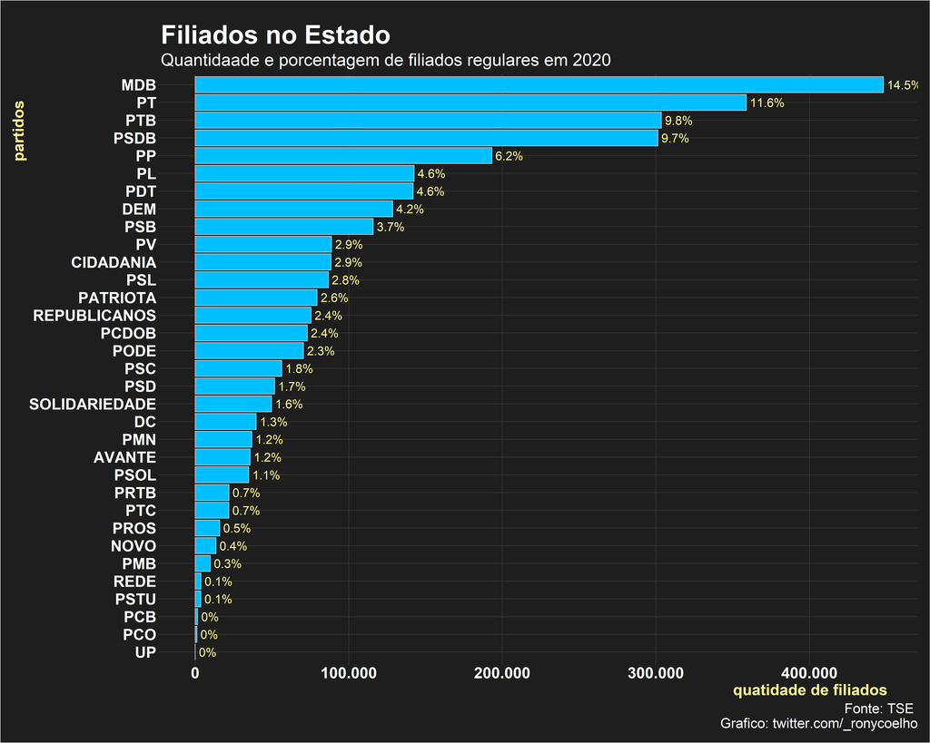

No entanto, na capital paulista, as primeiras posições se invertem, sendo o PT a ocupar o primeiro lugar e o segundo, (P)MDB. Em São Paulo, o PT tem quase 120 mil eleitores filiados, representando aproximadamente 22% do total. As posições subsequente ficam bem abaixo dessa marca: (P)MDB(14,3%), PTB(13%), PSDB(6,6%).

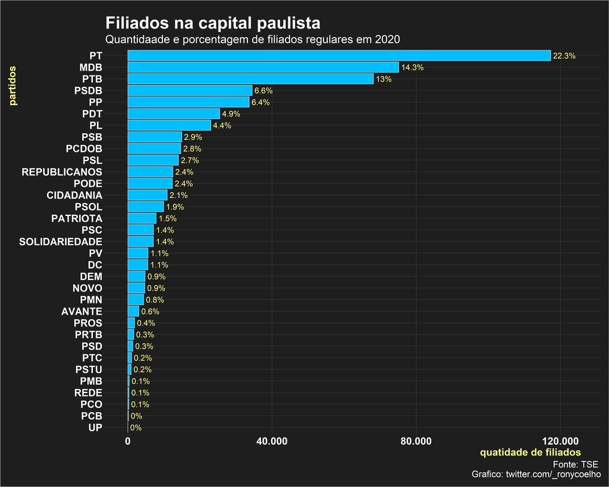

Os partidos que ocupam as primeiras posições são também os mais antigos, segundo o registro [formalizado no TSE](http://www.tse.jus.br/partidos/partidos-politicos/registrados-no-tse), representado abaixo pela linha vermelha. O histórico de filiação de cada partido, na capital paulista, é registrado neste gráfico. Nota-se, em quase todos os casos, picos coincidentes com anos eleitorais. No caso do PT, um grande número de pessoas se filiou em 2004, quando da disputa de Marta Suplicy para reeleição. Nos anos mais recentes, é possível perceber o aumento da filiação no PSL, partido pelo qual Bolsonaro (hoje sem partido) disputou as eleições em 2018.

[figure not shown]

Tomando os ultimos 5 anos, em número totais, o PSL foi o partido que mais recebeu simpatizantes, mas praticamente a totalidade concentrada em 2018. Antes os números de novas filiações eram pífios e depois reduziram drásticamente. Em 2019, filiou menos da metade do que em 2018. Movimento inverso seguiu o PT, que em 2018 recebeu aproximadamente 2.000 filiados e, em 2019, 4.000.

[figure not shown]

Em relação às desfiliações, ocupa o primeiro lugar o partido Novo (o chamado PSL Personallitè). O PSL, além de ter queda no número de filiações em 2019, teve aumento das desfiliações, provavelmente seguindo os movimentos dos milicianos. Em terceiro lugar aparece o PSOL, seguido do PSDB, mas com número de desfiliações bastante baixo (abaixo de 100).

[figure not shown]

[^1]: Meireles, Fernando; Silva, Denisson; Costa, Beatriz. (2016). electionsBR: R functions todownload and clean Brazilian electoral data. URL: http://electionsbr.com/